# Analisis Rancangan Percobaan Germination

Ibrahim Zaidan

2025-12-03

```r
ensure_pkg <- function(pkg){
  if(!require(pkg, character.only = TRUE)){
    install.packages(pkg, dependencies = TRUE)
    library(pkg, character.only = TRUE)
  }
}
pkgs <- c("tidyverse", "car", "ggplot2", "dplyr", "performance",
          "ggpubr", "DescTools")
lapply(pkgs, ensure_pkg)
```

# Persiapan Data

## Import Data

```r
data_path <- "C:/Users/De Ibrahim/kuliah/sem 5/Kuliah/germination.data.csv"
df <- read.csv(data_path)
```

Terdapat 1440 amatan dan 5 peubah.

## Cek missing values

```r
colSums(is.na(df))
```

```
##     Species       Patch     Microbe  Germinated Total_Seeds
##           0           0           0           0           0
```

Tidak ada missing values

## Buat proporsi germination

```r
df <- df %>%
mutate(Prop = Germinated / Total_Seeds,
Species = as.factor(Species),
Microbe = as.factor(Microbe))
df %>%
group_by(Species, Microbe) %>%
summarise(mean_prop = mean(Prop), sd_prop = sd(Prop),
n = n(), .groups="drop") %>%
head()
```

| Species | Microbe | mean_prop | sd_prop | n |
| --- | --- | --- | --- | --- |
| Balduina_angustifolia | L | 0.4015873 | 0.1349935 | 63 |
| Balduina_angustifolia | S | 0.4039683 | 0.1519501 | 63 |
| Chamaecrista_fasciculata | L | 0.8465608 | 0.2226059 | 63 |
| Chamaecrista_fasciculata | S | 0.8624339 | 0.1952383 | 63 |
| Chapmannia_floridana | L | 0.7469136 | 0.2418340 | 27 |
| Chapmannia_floridana | S | 0.7407407 | 0.2668803 | 27 |

Kita coba hanya pakai 2 peubah, yaitu ukuran (Microbe) dan Spesiesnya (Species)

# Eksplorasi Data

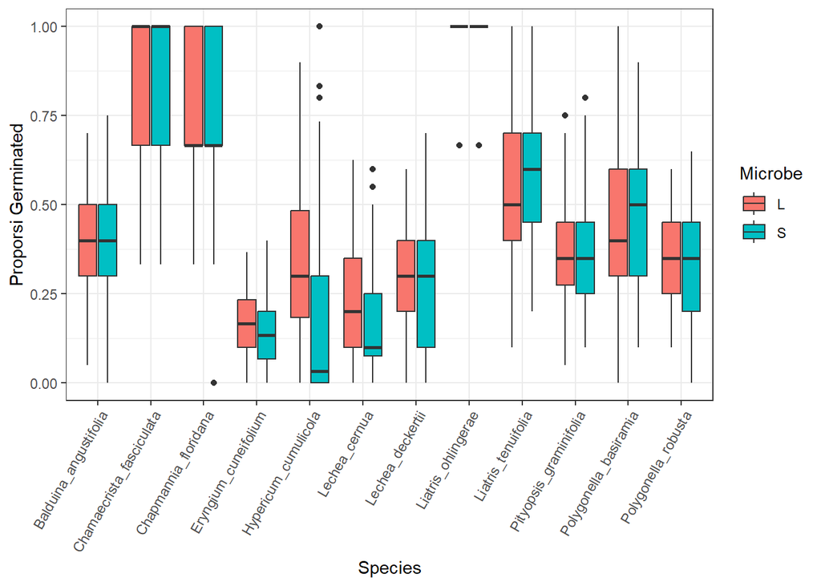

```r
ggplot(df, aes(x = Species, y = Prop, fill = Microbe)) +
geom_boxplot() +
theme_bw() +
theme(axis.text.x = element_text(angle = 60, hjust = 1)) +
ylab("Proporsi Germinated")
```

Secara visual, interaksi Species × Microbe kemungkinan signifikan, tetapi ada kemungkinan melanggar asumsi homogenitas varians.

## Histogra distribusi data

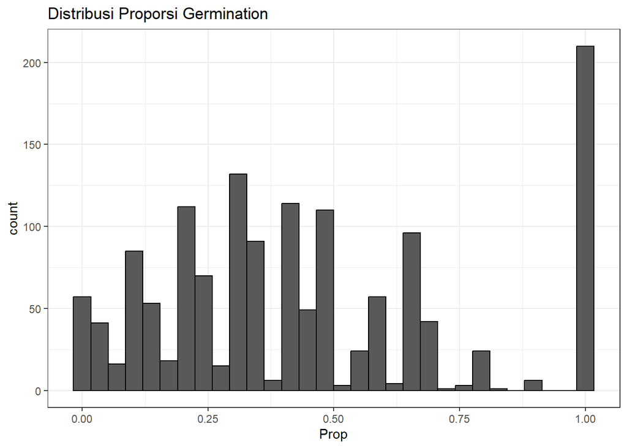

```r
ggplot(df, aes(Prop)) +
geom_histogram(bins = 30, color="black") +
theme_bw() +
ggtitle("Distribusi Proporsi Germination")
```

Data tidak normal, ada spike yang besar di 1, perlu transformasi arcsine.

## Transformasi arcsine square-root

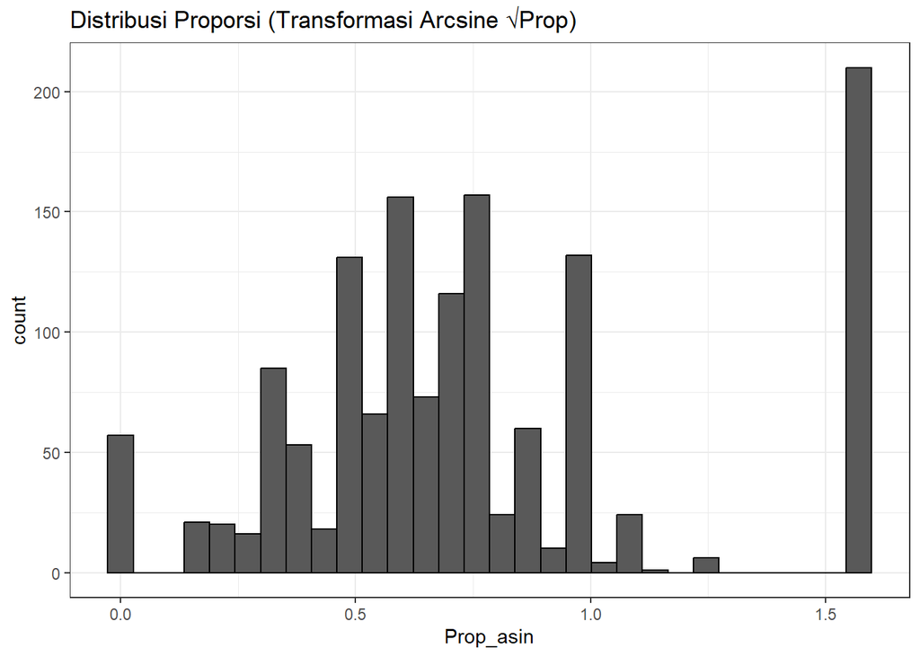

```r
df <- df %>%
mutate(Prop_asin = asin(sqrt(Prop)))
ggplot(df, aes(Prop_asin)) +
geom_histogram(bins = 30, color="black") +
theme_bw() +
ggtitle("Distribusi Proporsi (Transformasi Arcsine √Prop)")
```

# ANOVA dua arah

```r
anova_asin <- aov(Prop_asin ~ Species * Microbe, data = df)
summary(anova_asin)
```

```
##                   Df Sum Sq Mean Sq F value   Pr(>F)
## Species           11 164.73  14.976 268.552  < 2e-16 ***
## Microbe            1   0.26   0.265   4.751   0.0294 *
## Species:Microbe   11   2.56   0.233   4.173 4.26e-06 ***
## Residuals       1416  78.96   0.056
## ---
## Signif. codes:  0 '***' 0.001 '**' 0.01 '*' 0.05 '.' 0.1 ' ' 1
```

p value species kurang dari 0.05 menunjukkan Species memberikan pengaruh yang sangat kuat dan dominan terhadap proporsi perkecambahan yang sudah ditransformasi.

untuk Microbe, p valuenya juga kurang dari 0.05 menunjukkan bahwa microbe berpengaruh signifikan terhadap proporsi perkecambahan.

Untuk interaksi Species × Microb juga menunjukkan p value kurang dari 0.05, artinya terdapat interaksi yang signifikan, artinya efek mikroba berubah-ubah tergantung spesiesnya.

# Effect-size ANOVA

```r
library(effectsize)
library(DescTools)
eta_squared(anova_asin)
```

| Parameter | Eta2_partial | CI | CI_low | CI_high |
| --- | --- | --- | --- | --- |
| Species | 0.675978026 | 0.95 | 0.6554275791 | 1 |
| Microbe | 0.003343959 | 0.95 | 0.0001732564 | 1 |
| Species:Microbe | 0.031401201 | 0.95 | 0.0122037586 | 1 |

ini untuk hasil yang mempertimbangkan ukuran data, terlihat dari hasil ini bahwa spesies menjelaskan 68% variasi perkecambahan,Pengaruh mikroba secara langsung hampir tidak ada, dan Interaksi ada, tetapi kecil.

# Uji Asumsi

## Shapiro–Wilk

```r
resid_asin <- residuals(anova_asin)
shapiro.test(resid_asin)
```

```
##
##  Shapiro-Wilk normality test
##
## data:  resid_asin
## W = 0.98115, p-value = 8.597e-13
```

Walaupun berhasil ditransformasi menggunakan arscine, residual masih belom normal, tapi kasus ini umum untuk data proporsi besar dan ANOVA masih robust karena ukuran sampel sangat besar.

## Levene-test

```r
leveneTest(Prop_asin ~ Species * Microbe, data = df)
```

|  | Df | F value | Pr(>F) |
| --- | --- | --- | --- |
| group | 23 | 6.583699 | 1.131131e-19 |
|  | 1416 | NA | NA |

Varians antar grup tidak homogen.

## DW-test

```r
library(lmtest)
dwtest(Prop_asin ~ Species * Microbe, data = df)
```

```
##
##  Durbin-Watson test
##
## data:  Prop_asin ~ Species * Microbe
## DW = 2.0558, p-value = 0.7688
## alternative hypothesis: true autocorrelation is greater than 0
```

Tidak ada autokorelasi pada residual.

# Penanganan

Karena residual ANOVA melanggar asumsi normalitas dan homogenitas meskipun sudah ditransformasi, dan karena Y berupa data proporsi dengan batas 0–1, maka model terbaik adalah GLM dengan link logit (binomial).

## GLM Binomial

```r
glm_mod <- glm(cbind(Germinated, Total_Seeds - Germinated) ~ Species * Microbe,
               family = binomial, data = df)
summary(glm_mod)
```

```
##
## Call:
## glm(formula = cbind(Germinated, Total_Seeds - Germinated) ~ Species *
##     Microbe, family = binomial, data = df)
##
## Coefficients:
##                                           Estimate Std. Error z value Pr(>|z|)
## (Intercept)                              -0.398856   0.057468  -6.941 3.91e-12
## SpeciesChamaecrista_fasciculata           2.125310   0.209572  10.141  < 2e-16
## SpeciesChapmannia_floridana               1.465207   0.259451   5.647 1.63e-08
## SpeciesEryngium_cuneifolium              -1.225898   0.084565 -14.496  < 2e-16
## SpeciesHypericum_cumulicola              -0.299057   0.075414  -3.966 7.32e-05
## SpeciesLechea_cernua                     -0.741868   0.086944  -8.533  < 2e-16
## SpeciesLechea_deckertii                  -0.548758   0.105769  -5.188 2.12e-07
## SpeciesLiatris_ohlingerae                 2.924584   0.283629  10.311  < 2e-16
## SpeciesLiatris_tenuifolia                 0.518160   0.098827   5.243 1.58e-07
## SpeciesPityopsis_graminifolia            -0.175131   0.082133  -2.132 0.032984
## SpeciesPolygonella_basiramia              0.162846   0.098694   1.650 0.098943
## SpeciesPolygonella_robusta               -0.230666   0.082475  -2.797 0.005161
## MicrobeS                                  0.009898   0.081233   0.122 0.903019
## SpeciesChamaecrista_fasciculata:MicrobeS  0.129515   0.302705   0.428 0.668754
## SpeciesChapmannia_floridana:MicrobeS     -0.060329   0.368065  -0.164 0.869803
## SpeciesEryngium_cuneifolium:MicrobeS     -0.252375   0.122519  -2.060 0.039410
## SpeciesHypericum_cumulicola:MicrobeS     -0.850718   0.112340  -7.573 3.65e-14
## SpeciesLechea_cernua:MicrobeS            -0.428040   0.127993  -3.344 0.000825
## SpeciesLechea_deckertii:MicrobeS          0.059997   0.148781   0.403 0.686761
## SpeciesLiatris_ohlingerae:MicrobeS        0.349174   0.435118   0.802 0.422275
## SpeciesLiatris_tenuifolia:MicrobeS        0.194746   0.139966   1.391 0.164110
## SpeciesPityopsis_graminifolia:MicrobeS   -0.013343   0.116141  -0.115 0.908535
## SpeciesPolygonella_basiramia:MicrobeS     0.086202   0.139345   0.619 0.536167
## SpeciesPolygonella_robusta:MicrobeS      -0.109456   0.117106  -0.935 0.349958
##
## (Intercept)                              ***
## SpeciesChamaecrista_fasciculata          ***
## SpeciesChapmannia_floridana              ***
## SpeciesEryngium_cuneifolium              ***
## SpeciesHypericum_cumulicola              ***
## SpeciesLechea_cernua                     ***
## SpeciesLechea_deckertii                  ***
## SpeciesLiatris_ohlingerae                ***
```

[output cut: 11 more lines]

```
## SpeciesLiatris_ohlingerae:MicrobeS
## SpeciesLiatris_tenuifolia:MicrobeS
## SpeciesPityopsis_graminifolia:MicrobeS
## SpeciesPolygonella_basiramia:MicrobeS
## SpeciesPolygonella_robusta:MicrobeS
## ---
## Signif. codes:  0 '***' 0.001 '**' 0.01 '*' 0.05 '.' 0.1 ' ' 1
##
## (Dispersion parameter for binomial family taken to be 1)
##
##     Null deviance: 6112.6  on 1439  degrees of freedom
## Residual deviance: 3405.4  on 1416  degrees of freedom
## AIC: 6828.8
##
## Number of Fisher Scoring iterations: 5
```

Dari hasil GLM, ditunjukkan bahwa species adalah driver utama perkecambaha,Microbe S secara umum tidak berpengaruh, Interaksi Species × Microbe signifikan hanya pada beberapa spesies, dan arahnya negatif.

## Plot Interaksi

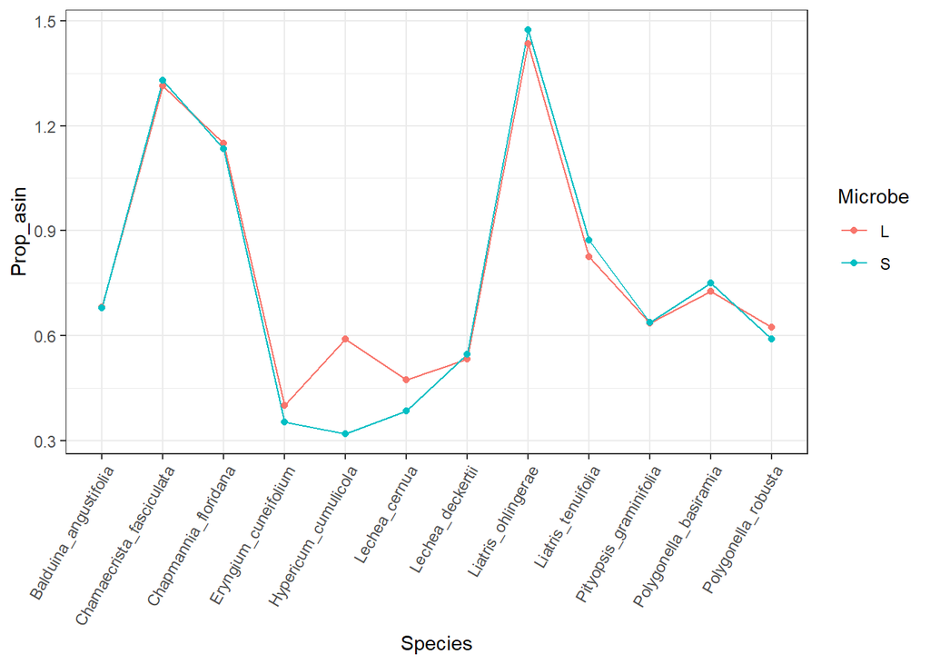

```r
ggplot(df, aes(Species, Prop_asin, color = Microbe, group = Microbe)) +
  stat_summary(fun = mean, geom = "line") +
  stat_summary(fun = mean, geom = "point") +
  theme_bw() +
  theme(axis.text.x = element_text(angle=60, hjust=1))
```

Perbedaan antar spesies sangat mencolok, sehingga faktor ‘Species’ menjadi penjelas utama variasi perkecambahan.

# Kesimpulan

GLM menunjukkan hasil yang paling tepat untuk data proporsi dan menegaskan bahwa Species adalah faktor utama yang menentukan tingkat perkecambahan. Pengaruh Microbe sangat kecil, dan interaksi Species × Microbe hanya muncul pada sedikit spesies. Hasil ini sejalan dengan effect size ANOVA yang juga menunjukkan dominasi faktor Species. Dengan demikian, variasi perkecambahan terutama ditentukan oleh perbedaan antar spesies, bukan oleh perlakuan mikroba.